# CIEPS

Autor

Fernando Náufel

Data de Publicação

03/07/2025 17:25

# Dados

```r
df <- ler_dados()
nparticipantes <- nrow(df)
```

Foram lidos dados de 78 participantes:

```r
df %>% dfSummary() %>% print(method = 'render')
```

| **Variável** | **Estatísticas / Valores** | **Freqs (% de Válidos)** | **Grafo** | **Faltante** |
| --- | --- | --- | --- | --- |
| data [character] | 1. 10/10/2024 2. 21/08/2024 3. 29/08/2024 | 12 ( 17,9% ) 42 ( 62,7% ) 13 ( 19,4% ) |  | 11 (14,1%) |
| nome [character] | 1. Ana Clara 2. Jullia 3. Leticia 4. Marcos 5. Maria 6. 1 7. 22 8. 23 9. 24 10. 25 [ 63 outros ] | 2 ( 2,6% ) 2 ( 2,6% ) 2 ( 2,6% ) 2 ( 2,6% ) 2 ( 2,6% ) 1 ( 1,3% ) 1 ( 1,3% ) 1 ( 1,3% ) 1 ( 1,3% ) 1 ( 1,3% ) 63 ( 80,8% ) |  | 0 (0,0%) |
| distraido [logical] | 1. FALSE 2. TRUE | 70 ( 89,7% ) 8 ( 10,3% ) |  | 0 (0,0%) |
| nquestoes_parte1 [numeric] | 1 valor distinto | 16 : 78 ( 100,0% ) |  | 0 (0,0%) |
| acertos_parte1 [numeric] | Média (dp) : 9,8 (3,1) mín < mediana < máx: 2 < 10 < 15 IQE (CV) : 4,8 (0,3) | 13 valores distintos |  | 0 (0,0%) |
| pct_parte1 [numeric] | Média (dp) : 61,2 (19,5) mín < mediana < máx: 12,5 < 62,5 < 93,8 IQE (CV) : 29,7 (0,3) | 13 valores distintos |  | 0 (0,0%) |
| nquestoes_parte2 [numeric] | Média (dp) : 9,9 (5,5) mín < mediana < máx: 2 < 15 < 15 IQE (CV) : 10 (0,6) | 2 : 12 ( 15,4% ) 5 : 13 ( 16,7% ) 6 : 12 ( 15,4% ) 15 : 41 ( 52,6% ) |  | 0 (0,0%) |
| acertos_parte2 [numeric] | Média (dp) : 5 (3,3) mín < mediana < máx: 0 < 4 < 14 IQE (CV) : 4 (0,6) | 14 valores distintos |  | 0 (0,0%) |
| pct_parte2 [numeric] | Média (dp) : 53,2 (21,1) mín < mediana < máx: 0 < 50 < 100 IQE (CV) : 13,3 (0,4) | 16 valores distintos |  | 0 (0,0%) |
| grupo [character] | 1. aula 2. jogo | 41 ( 52,6% ) 37 ( 47,4% ) |  | 0 (0,0%) |
| acertos [numeric] | Média (dp) : 14,8 (4,6) mín < mediana < máx: 4 < 15 < 26 IQE (CV) : 5 (0,3) | 20 valores distintos |  | 0 (0,0%) |
| questoes [numeric] | Média (dp) : 25,9 (5,5) mín < mediana < máx: 18 < 31 < 31 IQE (CV) : 10 (0,2) | 18 : 12 ( 15,4% ) 21 : 13 ( 16,7% ) 22 : 12 ( 15,4% ) 31 : 41 ( 52,6% ) |  | 0 (0,0%) |
| pct [numeric] | Média (dp) : 58,8 (18) mín < mediana < máx: 12,9 < 57,6 < 88,9 IQE (CV) : 23 (0,3) | 39 valores distintos |  | 0 (0,0%) |

Gerado por summarytools 1.0.1 ([R](https://www.r-project.org/) versão 4.3.3)  
2025-07-03

No sumário acima, a variável `questoes` contém a quantidade de questões (parte 1 mais parte 2) respondidas pelo participante.

# Escolher alunos

- Mesma qtde de alunos em cada grupo.
- Excluir distraídos ou não?

## Quantos não-distraídos na aula?

```r
df %>%
  group_by(grupo) %>%
  count(distraido)
```

| grupo | distraido | n |
| --- | --- | --- |
| aula | FALSE | 33 |
| aula | TRUE | 8 |
| jogo | FALSE | 37 |

# 37 em cada grupo

Obrigatoriamente, 4 dorminhocos no grupo aula.

## Definir grupos

```r
n_aula <- 37
n_jogo <- 37

df <- df %>% escolher_grupos(n_aula, n_jogo)
df_jogo <- df %>% filter(grupo == 'jogo')
df_aula <- df %>% filter(grupo == 'aula')
```

```r
df %>% dfSummary() %>% print(method = 'render')
```

```
temporary images written to '/home/fnaufel/Documents/Research/Estressilhados/2024-10-cieps/analise-cieps/dfimg'
```

| **Variável** | **Estatísticas / Valores** | **Freqs (% de Válidos)** | **Grafo** | **Faltante** |
| --- | --- | --- | --- | --- |
| data [character] | 1. 10/10/2024 2. 21/08/2024 3. 29/08/2024 | 12 ( 18,5% ) 40 ( 61,5% ) 13 ( 20,0% ) |  | 9 (12,2%) |
| nome [character] | 1. Ana Clara 2. Jullia 3. Leticia 4. Marcos 5. Maria 6. 1 7. 22 8. 23 9. 24 10. 25 [ 59 outros ] | 2 ( 2,7% ) 2 ( 2,7% ) 2 ( 2,7% ) 2 ( 2,7% ) 2 ( 2,7% ) 1 ( 1,4% ) 1 ( 1,4% ) 1 ( 1,4% ) 1 ( 1,4% ) 1 ( 1,4% ) 59 ( 79,7% ) |  | 0 (0,0%) |
| distraido [logical] | 1. FALSE 2. TRUE | 70 ( 94,6% ) 4 ( 5,4% ) |  | 0 (0,0%) |
| nquestoes_parte1 [numeric] | 1 valor distinto | 16 : 74 ( 100,0% ) |  | 0 (0,0%) |
| acertos_parte1 [numeric] | Média (dp) : 9,9 (3,1) mín < mediana < máx: 2 < 10 < 15 IQE (CV) : 4 (0,3) | 13 valores distintos |  | 0 (0,0%) |
| pct_parte1 [numeric] | Média (dp) : 62,2 (19,4) mín < mediana < máx: 12,5 < 62,5 < 93,8 IQE (CV) : 25 (0,3) | 13 valores distintos |  | 0 (0,0%) |
| nquestoes_parte2 [numeric] | Média (dp) : 9,7 (5,5) mín < mediana < máx: 2 < 10,5 < 15 IQE (CV) : 10 (0,6) | 2 : 12 ( 16,2% ) 5 : 13 ( 17,6% ) 6 : 12 ( 16,2% ) 15 : 37 ( 50,0% ) |  | 0 (0,0%) |
| acertos_parte2 [numeric] | Média (dp) : 5 (3,3) mín < mediana < máx: 0 < 4 < 14 IQE (CV) : 4,8 (0,7) | 14 valores distintos |  | 0 (0,0%) |
| pct_parte2 [numeric] | Média (dp) : 54,2 (20,6) mín < mediana < máx: 0 < 51,7 < 100 IQE (CV) : 13,3 (0,4) | 16 valores distintos |  | 0 (0,0%) |
| grupo [character] | 1. aula 2. jogo | 37 ( 50,0% ) 37 ( 50,0% ) |  | 0 (0,0%) |
| acertos [numeric] | Média (dp) : 15 (4,5) mín < mediana < máx: 5 < 15 < 26 IQE (CV) : 5,8 (0,3) | 19 valores distintos |  | 0 (0,0%) |
| questoes [numeric] | Média (dp) : 25,7 (5,5) mín < mediana < máx: 18 < 26,5 < 31 IQE (CV) : 10 (0,2) | 18 : 12 ( 16,2% ) 21 : 13 ( 17,6% ) 22 : 12 ( 16,2% ) 31 : 37 ( 50,0% ) |  | 0 (0,0%) |
| pct [numeric] | Média (dp) : 59,9 (17,5) mín < mediana < máx: 16,1 < 58,1 < 88,9 IQE (CV) : 23,2 (0,3) | 38 valores distintos |  | 0 (0,0%) |

Gerado por summarytools 1.0.1 ([R](https://www.r-project.org/) versão 4.3.3)  
2025-07-03

```r
df_jogo %>% dfSummary() %>% print(method = 'render')
```

```
temporary images written to '/home/fnaufel/Documents/Research/Estressilhados/2024-10-cieps/analise-cieps/dfimg'
```

| **Variável** | **Estatísticas / Valores** | **Freqs (% de Válidos)** | **Grafo** | **Faltante** |
| --- | --- | --- | --- | --- |
| data [character] | 1. 10/10/2024 2. 21/08/2024 3. 29/08/2024 | 12 ( 32,4% ) 12 ( 32,4% ) 13 ( 35,1% ) |  | 0 (0,0%) |
| nome [character] | 1. Ana Clara 2. Antonio 3. Bruno 4. Emilly 5. Gabrielle 6. Geysiane 7. Izabel 8. Izock 9. Jennifer 10. Joao [ 27 outros ] | 1 ( 2,7% ) 1 ( 2,7% ) 1 ( 2,7% ) 1 ( 2,7% ) 1 ( 2,7% ) 1 ( 2,7% ) 1 ( 2,7% ) 1 ( 2,7% ) 1 ( 2,7% ) 1 ( 2,7% ) 27 ( 73,0% ) |  | 0 (0,0%) |
| distraido [logical] | 1. FALSE | 37 ( 100,0% ) |  | 0 (0,0%) |
| nquestoes_parte1 [numeric] | 1 valor distinto | 16 : 37 ( 100,0% ) |  | 0 (0,0%) |
| acertos_parte1 [numeric] | Média (dp) : 10,9 (2,9) mín < mediana < máx: 4 < 11 < 15 IQE (CV) : 4 (0,3) | 11 valores distintos |  | 0 (0,0%) |
| pct_parte1 [numeric] | Média (dp) : 67,9 (18) mín < mediana < máx: 25 < 68,8 < 93,8 IQE (CV) : 25 (0,3) | 11 valores distintos |  | 0 (0,0%) |
| nquestoes_parte2 [numeric] | Média (dp) : 4,4 (1,7) mín < mediana < máx: 2 < 5 < 6 IQE (CV) : 4 (0,4) | 2 : 12 ( 32,4% ) 5 : 13 ( 35,1% ) 6 : 12 ( 32,4% ) |  | 0 (0,0%) |
| acertos_parte2 [numeric] | Média (dp) : 2,5 (1,3) mín < mediana < máx: 0 < 3 < 5 IQE (CV) : 2 (0,5) | 0 : 1 ( 2,7% ) 1 : 10 ( 27,0% ) 2 : 6 ( 16,2% ) 3 : 13 ( 35,1% ) 4 : 3 ( 8,1% ) 5 : 4 ( 10,8% ) |  | 0 (0,0%) |
| pct_parte2 [numeric] | Média (dp) : 58 (23) mín < mediana < máx: 0 < 50 < 100 IQE (CV) : 16,7 (0,4) | 0,00 : 1 ( 2,7% ) 20,00 : 2 ( 5,4% ) NANA : 3 ( 8,1% ) 50,00 : 13 ( 35,1% ) 60,00 : 8 ( 21,6% ) NANA : 1 ( 2,7% ) 80,00 : 2 ( 5,4% ) NANA : 3 ( 8,1% ) 100,00 : 4 ( 10,8% ) |  | 0 (0,0%) |
| grupo [character] | 1. jogo | 37 ( 100,0% ) |  | 0 (0,0%) |
| acertos [numeric] | Média (dp) : 13,4 (3,1) mín < mediana < máx: 6 < 13 < 19 IQE (CV) : 5 (0,2) | 12 valores distintos |  | 0 (0,0%) |
| questoes [numeric] | Média (dp) : 20,4 (1,7) mín < mediana < máx: 18 < 21 < 22 IQE (CV) : 4 (0,1) | 18 : 12 ( 32,4% ) 21 : 13 ( 35,1% ) 22 : 12 ( 32,4% ) |  | 0 (0,0%) |
| pct [numeric] | Média (dp) : 66,2 (16,2) mín < mediana < máx: 27,3 < 66,7 < 88,9 IQE (CV) : 25,4 (0,2) | 21 valores distintos |  | 0 (0,0%) |

Gerado por summarytools 1.0.1 ([R](https://www.r-project.org/) versão 4.3.3)  
2025-07-03

**Erro em `dfSummary`**

Aparecem NAs em `pct_parte2`, mas só na tabela retornada por `dfSummary`.

Alguma coisa causada por `round.digits` e valores que são dízimas.

O dataframe continua correto.

```r
df_aula %>% dfSummary() %>% print(method = 'render')
```

```
temporary images written to '/home/fnaufel/Documents/Research/Estressilhados/2024-10-cieps/analise-cieps/dfimg'
```

| **Variável** | **Estatísticas / Valores** | **Freqs (% de Válidos)** | **Grafo** | **Faltante** |
| --- | --- | --- | --- | --- |
| data [character] | 1. 21/08/2024 | 28 ( 100,0% ) |  | 9 (24,3%) |
| nome [character] | 1. 1 2. 22 3. 23 4. 24 5. 25 6. 30 7. Alessandra 8. Alexa 9. Ana 10. Ana Clara [ 27 outros ] | 1 ( 2,7% ) 1 ( 2,7% ) 1 ( 2,7% ) 1 ( 2,7% ) 1 ( 2,7% ) 1 ( 2,7% ) 1 ( 2,7% ) 1 ( 2,7% ) 1 ( 2,7% ) 1 ( 2,7% ) 27 ( 73,0% ) |  | 0 (0,0%) |
| distraido [logical] | 1. FALSE 2. TRUE | 33 ( 89,2% ) 4 ( 10,8% ) |  | 0 (0,0%) |
| nquestoes_parte1 [numeric] | 1 valor distinto | 16 : 37 ( 100,0% ) |  | 0 (0,0%) |
| acertos_parte1 [numeric] | Média (dp) : 9 (3,1) mín < mediana < máx: 2 < 9 < 14 IQE (CV) : 4 (0,3) | 11 valores distintos |  | 0 (0,0%) |
| pct_parte1 [numeric] | Média (dp) : 56,4 (19,3) mín < mediana < máx: 12,5 < 56,2 < 87,5 IQE (CV) : 25 (0,3) | 11 valores distintos |  | 0 (0,0%) |
| nquestoes_parte2 [numeric] | 1 valor distinto | 15 : 37 ( 100,0% ) |  | 0 (0,0%) |
| acertos_parte2 [numeric] | Média (dp) : 7,6 (2,6) mín < mediana < máx: 2 < 8 < 14 IQE (CV) : 3 (0,3) | 12 valores distintos |  | 0 (0,0%) |
| pct_parte2 [numeric] | Média (dp) : 50,5 (17,5) mín < mediana < máx: 13,3 < 53,3 < 93,3 IQE (CV) : 20 (0,3) | 12 valores distintos |  | 0 (0,0%) |
| grupo [character] | 1. aula | 37 ( 100,0% ) |  | 0 (0,0%) |
| acertos [numeric] | Média (dp) : 16,6 (5,1) mín < mediana < máx: 5 < 17 < 26 IQE (CV) : 6 (0,3) | 17 valores distintos |  | 0 (0,0%) |
| questoes [numeric] | 1 valor distinto | 31 : 37 ( 100,0% ) |  | 0 (0,0%) |
| pct [numeric] | Média (dp) : 53,5 (16,6) mín < mediana < máx: 16,1 < 54,8 < 83,9 IQE (CV) : 19,4 (0,3) | 17 valores distintos |  | 0 (0,0%) |

Gerado por summarytools 1.0.1 ([R](https://www.r-project.org/) versão 4.3.3)  
2025-07-03

```r
df
```

| data | nome | distraido | nquestoes_parte1 | acertos_parte1 | pct_parte1 | nquestoes_parte2 | acertos_parte2 | pct_parte2 | grupo | acertos | questoes | pct |
| --- | --- | --- | --- | --- | --- | --- | --- | --- | --- | --- | --- | --- |
| 10/10/2024 | Gabrielle | FALSE | 16 | 14 | 87,50 | 6 | 5 | 83,33333 | jogo | 19 | 22 | 86,36364 |
| 29/08/2024 | Lucas | FALSE | 16 | 10 | 62,50 | 5 | 3 | 60,00000 | jogo | 13 | 21 | 61,90476 |
| 29/08/2024 | Jullia | FALSE | 16 | 13 | 81,25 | 5 | 4 | 80,00000 | jogo | 17 | 21 | 80,95238 |
| 21/08/2024 | Leticia | FALSE | 16 | 11 | 68,75 | 2 | 1 | 50,00000 | jogo | 12 | 18 | 66,66667 |
| 21/08/2024 | Joao | FALSE | 16 | 15 | 93,75 | 2 | 1 | 50,00000 | jogo | 16 | 18 | 88,88889 |
| 21/08/2024 | Larissa | FALSE | 16 | 12 | 75,00 | 2 | 1 | 50,00000 | jogo | 13 | 18 | 72,22222 |
| 10/10/2024 | Tainá | FALSE | 16 | 4 | 25,00 | 6 | 2 | 33,33333 | jogo | 6 | 22 | 27,27273 |
| 21/08/2024 | Julia Macedo | FALSE | 16 | 13 | 81,25 | 2 | 2 | 100,00000 | jogo | 15 | 18 | 83,33333 |
| 21/08/2024 | Julia | FALSE | 16 | 15 | 93,75 | 2 | 1 | 50,00000 | jogo | 16 | 18 | 88,88889 |
| 21/08/2024 | Jennifer | FALSE | 16 | 9 | 56,25 | 2 | 1 | 50,00000 | jogo | 10 | 18 | 55,55556 |

[output cut: 64 more lines]

## Histogramas

```r
histogramas <- df %>% gerar_histogramas()
histograma_aula <- histogramas$aula
histograma_jogo <- histogramas$jogo
```

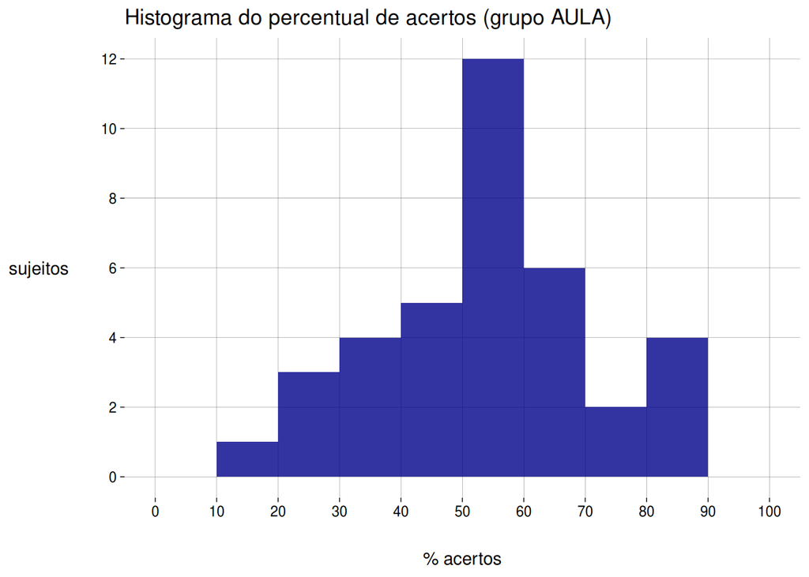

```r
histograma_aula
```

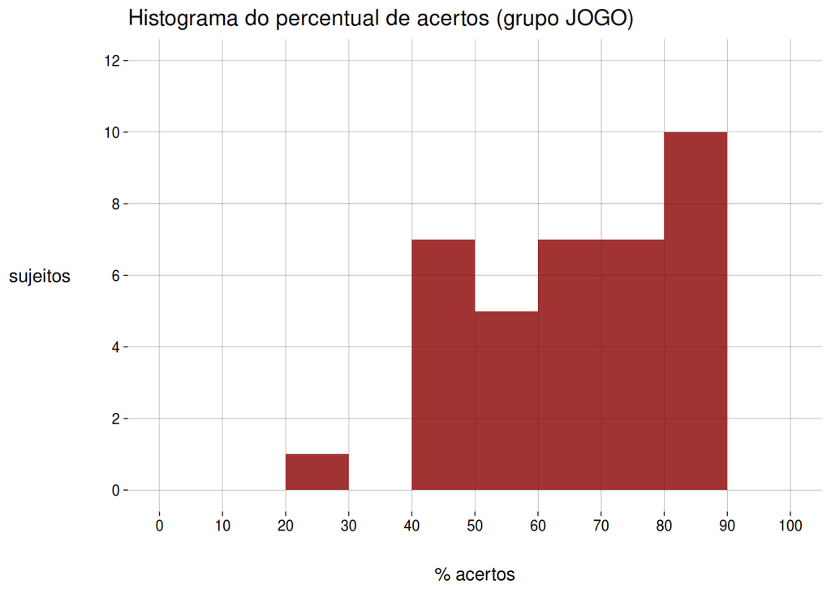

```r
histograma_jogo
```

## Intervalos de confiança

Para cada grupo, computamos intervalos de confiança de $95\%$ para o percentual médio de acertos, com os seguintes resultados:

```r
intervalos <- df %>% construir_intervalos()
```

```r
intervalos %>% tabela_intervalos()
```

| grupo | média | margem de erro | limite inferior | limite superior |
| --- | --- | --- | --- | --- |
| aula | 53,53 | ±5,53 | 48,00 | 59,06 |
| jogo | 66,22 | ±5,39 | 60,83 | 71,60 |

Graficamente:

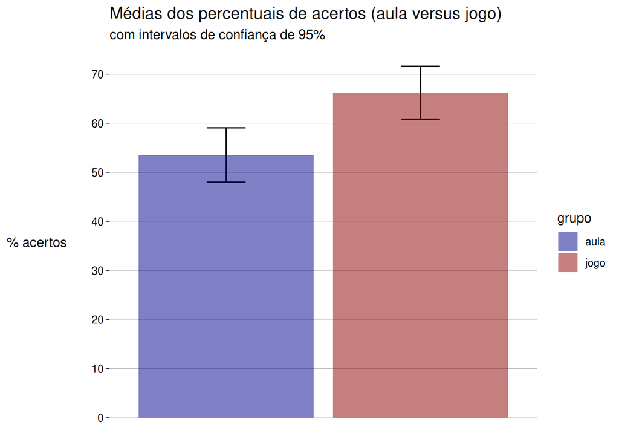

```r
intervalos %>% construir_plot_intervalos()
```

## Teste t

Para verificar se a diferença entre as médias dos percentuais de acertos é significativa, as seguintes hipóteses foram formuladas:

- A *hipótese de nulidade* $H_0$ diz que a média dos percentuais de acertos no grupo `jogo` ($\mu_\text{jogo}$) é *igual* à média dos percentuais de acertos no grupo `aula` ($\mu_\text{aula}$):

  $$H_0 : \mu_\text{jogo} = \mu_\text{aula}$$
- A *hipótese alternativa* $H_A$ diz que a média dos percentuais de acertos no grupo `jogo` ($\mu_\text{jogo}$) é *maior* do que a média dos percentuais de acertos no grupo `aula` ($\mu_\text{aula}$):

  $$H_A : \mu_\text{jogo} > \mu_\text{aula}$$

```r
t <- t.test(
  df %>% filter(grupo == 'jogo') %>% pull(pct),
  df %>% filter(grupo == 'aula') %>% pull(pct),
  alternative = 'greater',
  var.equal = TRUE
)

t
```

```
    Two Sample t-test

data:  df %>% filter(grupo == "jogo") %>% pull(pct) and df %>% filter(grupo == "aula") %>% pull(pct)
t = 3,3315, df = 72, p-value = 0,0006829
alternative hypothesis: true difference in means is greater than 0
95 percent confidence interval:
 6,340483      Inf
sample estimates:
mean of x mean of y
 66,21622  53,53095
```

Um *teste t* com $\alpha = 0{,}01$ rejeita a hipótese de nulidade com um valor-$p$ igual a $0{,}00068$, mostrando que *a diferença é significativa*.

Em outras palavras: se o jogo não tivesse efeito sobre o desempenho dos participantes no questionário, então uma diferença como a observada no experimento (ou maior) teria uma probabilidade muito pequena (de cerca de $0{,}07$%) de ocorrer.

# 33 em cada grupo

Nenhum dorminhoco.

## Definir grupos

```r
n_aula <- 33
n_jogo <- 33

df <- df %>% escolher_grupos(n_aula, n_jogo)
df_jogo <- df %>% filter(grupo == 'jogo')
df_aula <- df %>% filter(grupo == 'aula')
```

```r
df %>% dfSummary() %>% print(method = 'render')
```

```
temporary images written to '/home/fnaufel/Documents/Research/Estressilhados/2024-10-cieps/analise-cieps/dfimg'
```

| **Variável** | **Estatísticas / Valores** | **Freqs (% de Válidos)** | **Grafo** | **Faltante** |
| --- | --- | --- | --- | --- |
| data [character] | 1. 10/10/2024 2. 21/08/2024 3. 29/08/2024 | 10 ( 17,2% ) 35 ( 60,3% ) 13 ( 22,4% ) |  | 8 (12,1%) |
| nome [character] | 1. Ana Clara 2. Jullia 3. Leticia 4. Marcos 5. Maria 6. 1 7. 22 8. 23 9. 24 10. 25 [ 51 outros ] | 2 ( 3,0% ) 2 ( 3,0% ) 2 ( 3,0% ) 2 ( 3,0% ) 2 ( 3,0% ) 1 ( 1,5% ) 1 ( 1,5% ) 1 ( 1,5% ) 1 ( 1,5% ) 1 ( 1,5% ) 51 ( 77,3% ) |  | 0 (0,0%) |
| distraido [logical] | 1. FALSE | 66 ( 100,0% ) |  | 0 (0,0%) |
| nquestoes_parte1 [numeric] | 1 valor distinto | 16 : 66 ( 100,0% ) |  | 0 (0,0%) |
| acertos_parte1 [numeric] | Média (dp) : 10 (3) mín < mediana < máx: 2 < 10 < 15 IQE (CV) : 4 (0,3) | 13 valores distintos |  | 0 (0,0%) |
| pct_parte1 [numeric] | Média (dp) : 62,7 (19) mín < mediana < máx: 12,5 < 62,5 < 93,8 IQE (CV) : 25 (0,3) | 13 valores distintos |  | 0 (0,0%) |
| nquestoes_parte2 [numeric] | Média (dp) : 9,7 (5,5) mín < mediana < máx: 2 < 10,5 < 15 IQE (CV) : 10 (0,6) | 2 : 10 ( 15,2% ) 5 : 13 ( 19,7% ) 6 : 10 ( 15,2% ) 15 : 33 ( 50,0% ) |  | 0 (0,0%) |
| acertos_parte2 [numeric] | Média (dp) : 5,1 (3,3) mín < mediana < máx: 1 < 4 < 14 IQE (CV) : 4,8 (0,6) | 13 valores distintos |  | 0 (0,0%) |
| pct_parte2 [numeric] | Média (dp) : 55,3 (20) mín < mediana < máx: 13,3 < 53,3 < 100 IQE (CV) : 13,3 (0,4) | 15 valores distintos |  | 0 (0,0%) |
| grupo [character] | 1. aula 2. jogo | 33 ( 50,0% ) 33 ( 50,0% ) |  | 0 (0,0%) |
| acertos [numeric] | Média (dp) : 15,1 (4,6) mín < mediana < máx: 5 < 15 < 26 IQE (CV) : 6 (0,3) | 18 valores distintos |  | 0 (0,0%) |
| questoes [numeric] | Média (dp) : 25,7 (5,5) mín < mediana < máx: 18 < 26,5 < 31 IQE (CV) : 10 (0,2) | 18 : 10 ( 15,2% ) 21 : 13 ( 19,7% ) 22 : 10 ( 15,2% ) 31 : 33 ( 50,0% ) |  | 0 (0,0%) |
| pct [numeric] | Média (dp) : 60,3 (17,2) mín < mediana < máx: 16,1 < 58,1 < 88,9 IQE (CV) : 23,2 (0,3) | 36 valores distintos |  | 0 (0,0%) |

Gerado por summarytools 1.0.1 ([R](https://www.r-project.org/) versão 4.3.3)  
2025-07-03

```r
df_jogo %>% dfSummary() %>% print(method = 'render')
```

```
temporary images written to '/home/fnaufel/Documents/Research/Estressilhados/2024-10-cieps/analise-cieps/dfimg'
```

| **Variável** | **Estatísticas / Valores** | **Freqs (% de Válidos)** | **Grafo** | **Faltante** |
| --- | --- | --- | --- | --- |
| data [character] | 1. 10/10/2024 2. 21/08/2024 3. 29/08/2024 | 10 ( 30,3% ) 10 ( 30,3% ) 13 ( 39,4% ) |  | 0 (0,0%) |
| nome [character] | 1. Ana Clara 2. Antonio 3. Bruno 4. Gabrielle 5. Geysiane 6. Izabel 7. Izock 8. Jennifer 9. Joao 10. Joao Botelho [ 23 outros ] | 1 ( 3,0% ) 1 ( 3,0% ) 1 ( 3,0% ) 1 ( 3,0% ) 1 ( 3,0% ) 1 ( 3,0% ) 1 ( 3,0% ) 1 ( 3,0% ) 1 ( 3,0% ) 1 ( 3,0% ) 23 ( 69,7% ) |  | 0 (0,0%) |
| distraido [logical] | 1. FALSE | 33 ( 100,0% ) |  | 0 (0,0%) |
| nquestoes_parte1 [numeric] | 1 valor distinto | 16 : 33 ( 100,0% ) |  | 0 (0,0%) |
| acertos_parte1 [numeric] | Média (dp) : 10,8 (3) mín < mediana < máx: 4 < 11 < 15 IQE (CV) : 4 (0,3) | 11 valores distintos |  | 0 (0,0%) |
| pct_parte1 [numeric] | Média (dp) : 67,2 (18,7) mín < mediana < máx: 25 < 68,8 < 93,8 IQE (CV) : 25 (0,3) | 11 valores distintos |  | 0 (0,0%) |
| nquestoes_parte2 [numeric] | Média (dp) : 4,4 (1,7) mín < mediana < máx: 2 < 5 < 6 IQE (CV) : 4 (0,4) | 2 : 10 ( 30,3% ) 5 : 13 ( 39,4% ) 6 : 10 ( 30,3% ) |  | 0 (0,0%) |
| acertos_parte2 [numeric] | Média (dp) : 2,5 (1,3) mín < mediana < máx: 1 < 3 < 5 IQE (CV) : 2 (0,5) | 1 : 9 ( 27,3% ) 2 : 6 ( 18,2% ) 3 : 12 ( 36,4% ) 4 : 3 ( 9,1% ) 5 : 3 ( 9,1% ) |  | 0 (0,0%) |
| pct_parte2 [numeric] | Média (dp) : 59,5 (21,5) mín < mediana < máx: 20 < 60 < 100 IQE (CV) : 16,7 (0,4) | 20,00 : 2 ( 6,1% ) NANA : 3 ( 9,1% ) 50,00 : 11 ( 33,3% ) 60,00 : 8 ( 24,2% ) NANA : 1 ( 3,0% ) 80,00 : 2 ( 6,1% ) NANA : 2 ( 6,1% ) 100,00 : 4 ( 12,1% ) |  | 0 (0,0%) |
| grupo [character] | 1. jogo | 33 ( 100,0% ) |  | 0 (0,0%) |
| acertos [numeric] | Média (dp) : 13,3 (3,2) mín < mediana < máx: 6 < 13 < 19 IQE (CV) : 5 (0,2) | 12 valores distintos |  | 0 (0,0%) |
| questoes [numeric] | Média (dp) : 20,4 (1,7) mín < mediana < máx: 18 < 21 < 22 IQE (CV) : 4 (0,1) | 18 : 10 ( 30,3% ) 21 : 13 ( 39,4% ) 22 : 10 ( 30,3% ) |  | 0 (0,0%) |
| pct [numeric] | Média (dp) : 65,8 (16,6) mín < mediana < máx: 27,3 < 66,7 < 88,9 IQE (CV) : 25,4 (0,3) | 20 valores distintos |  | 0 (0,0%) |

Gerado por summarytools 1.0.1 ([R](https://www.r-project.org/) versão 4.3.3)  
2025-07-03

```r
df_aula %>% dfSummary() %>% print(method = 'render')
```

```
temporary images written to '/home/fnaufel/Documents/Research/Estressilhados/2024-10-cieps/analise-cieps/dfimg'
```

| **Variável** | **Estatísticas / Valores** | **Freqs (% de Válidos)** | **Grafo** | **Faltante** |
| --- | --- | --- | --- | --- |
| data [character] | 1. 21/08/2024 | 25 ( 100,0% ) |  | 8 (24,2%) |
| nome [character] | 1. 1 2. 22 3. 23 4. 24 5. 25 6. Alessandra 7. Alexa 8. Ana 9. Ana Clara 10. Ana Julia [ 23 outros ] | 1 ( 3,0% ) 1 ( 3,0% ) 1 ( 3,0% ) 1 ( 3,0% ) 1 ( 3,0% ) 1 ( 3,0% ) 1 ( 3,0% ) 1 ( 3,0% ) 1 ( 3,0% ) 1 ( 3,0% ) 23 ( 69,7% ) |  | 0 (0,0%) |
| distraido [logical] | 1. FALSE | 33 ( 100,0% ) |  | 0 (0,0%) |
| nquestoes_parte1 [numeric] | 1 valor distinto | 16 : 33 ( 100,0% ) |  | 0 (0,0%) |
| acertos_parte1 [numeric] | Média (dp) : 9,3 (3) mín < mediana < máx: 2 < 10 < 14 IQE (CV) : 4 (0,3) | 11 valores distintos |  | 0 (0,0%) |
| pct_parte1 [numeric] | Média (dp) : 58,1 (18,5) mín < mediana < máx: 12,5 < 62,5 < 87,5 IQE (CV) : 25 (0,3) | 11 valores distintos |  | 0 (0,0%) |
| nquestoes_parte2 [numeric] | 1 valor distinto | 15 : 33 ( 100,0% ) |  | 0 (0,0%) |
| acertos_parte2 [numeric] | Média (dp) : 7,7 (2,7) mín < mediana < máx: 2 < 8 < 14 IQE (CV) : 2 (0,3) | 12 valores distintos |  | 0 (0,0%) |
| pct_parte2 [numeric] | Média (dp) : 51,1 (17,7) mín < mediana < máx: 13,3 < 53,3 < 93,3 IQE (CV) : 13,3 (0,3) | 12 valores distintos |  | 0 (0,0%) |
| grupo [character] | 1. aula | 33 ( 100,0% ) |  | 0 (0,0%) |
| acertos [numeric] | Média (dp) : 17 (5) mín < mediana < máx: 5 < 17 < 26 IQE (CV) : 6 (0,3) | 16 valores distintos |  | 0 (0,0%) |
| questoes [numeric] | 1 valor distinto | 31 : 33 ( 100,0% ) |  | 0 (0,0%) |
| pct [numeric] | Média (dp) : 54,7 (16,1) mín < mediana < máx: 16,1 < 54,8 < 83,9 IQE (CV) : 19,4 (0,3) | 16 valores distintos |  | 0 (0,0%) |

Gerado por summarytools 1.0.1 ([R](https://www.r-project.org/) versão 4.3.3)  
2025-07-03

```r
df
```

| data | nome | distraido | nquestoes_parte1 | acertos_parte1 | pct_parte1 | nquestoes_parte2 | acertos_parte2 | pct_parte2 | grupo | acertos | questoes | pct |
| --- | --- | --- | --- | --- | --- | --- | --- | --- | --- | --- | --- | --- |
| 29/08/2024 | Izock | FALSE | 16 | 9 | 56,25 | 5 | 3 | 60,00000 | jogo | 12 | 21 | 57,14286 |
| 29/08/2024 | Maria Cecilia | FALSE | 16 | 14 | 87,50 | 5 | 4 | 80,00000 | jogo | 18 | 21 | 85,71429 |
| 29/08/2024 | Sarah | FALSE | 16 | 12 | 75,00 | 5 | 3 | 60,00000 | jogo | 15 | 21 | 71,42857 |
| 21/08/2024 | Julia | FALSE | 16 | 15 | 93,75 | 2 | 1 | 50,00000 | jogo | 16 | 18 | 88,88889 |
| 21/08/2024 | Joao | FALSE | 16 | 15 | 93,75 | 2 | 1 | 50,00000 | jogo | 16 | 18 | 88,88889 |
| 21/08/2024 | Larissa | FALSE | 16 | 12 | 75,00 | 2 | 1 | 50,00000 | jogo | 13 | 18 | 72,22222 |
| 10/10/2024 | Ana Clara | FALSE | 16 | 8 | 50,00 | 6 | 3 | 50,00000 | jogo | 11 | 22 | 50,00000 |
| 21/08/2024 | Leticia | FALSE | 16 | 11 | 68,75 | 2 | 1 | 50,00000 | jogo | 12 | 18 | 66,66667 |
| 29/08/2024 | Lucas | FALSE | 16 | 10 | 62,50 | 5 | 3 | 60,00000 | jogo | 13 | 21 | 61,90476 |
| 10/10/2024 | Tainá | FALSE | 16 | 4 | 25,00 | 6 | 2 | 33,33333 | jogo | 6 | 22 | 27,27273 |

[output cut: 56 more lines]

## Histogramas

```r
histogramas <- df %>% gerar_histogramas()
histograma_aula <- histogramas$aula
histograma_jogo <- histogramas$jogo
```

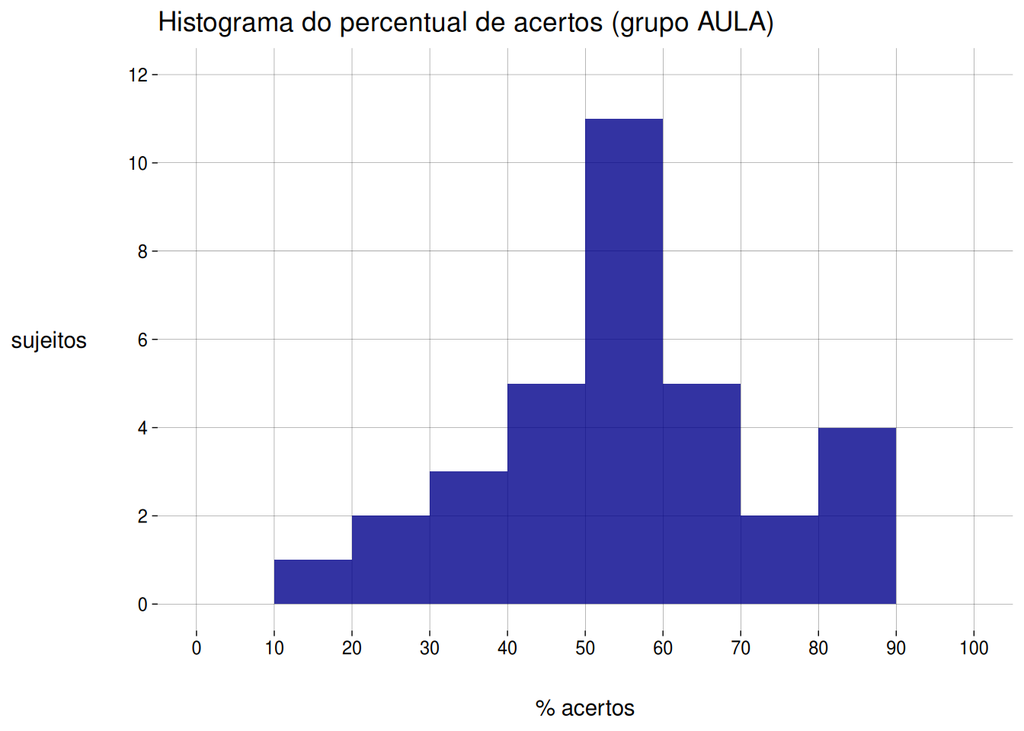

```r
histograma_aula
```

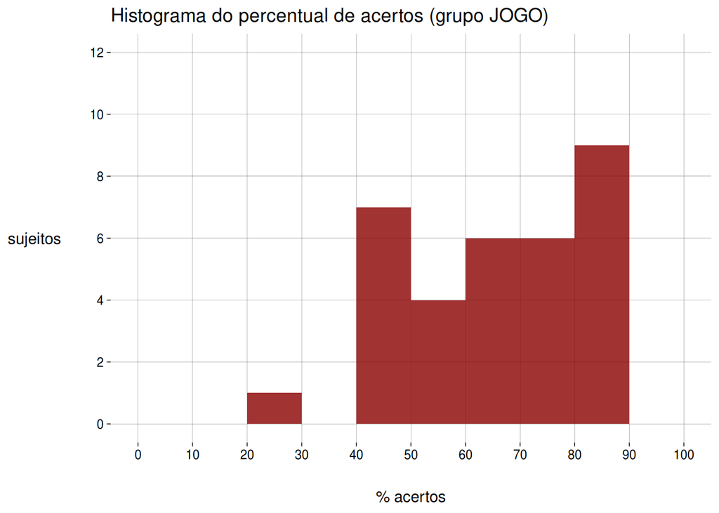

```r
histograma_jogo
```

## Intervalos de confiança

Para cada grupo, computamos intervalos de confiança de $95\%$ para o percentual médio de acertos, com os seguintes resultados:

```r
intervalos <- df %>% construir_intervalos()
```

```r
intervalos %>% tabela_intervalos()
```

| grupo | média | margem de erro | limite inferior | limite superior |
| --- | --- | --- | --- | --- |
| aula | 54,74 | ±5,72 | 49,02 | 60,46 |
| jogo | 65,76 | ±5,90 | 59,87 | 71,66 |

Graficamente:

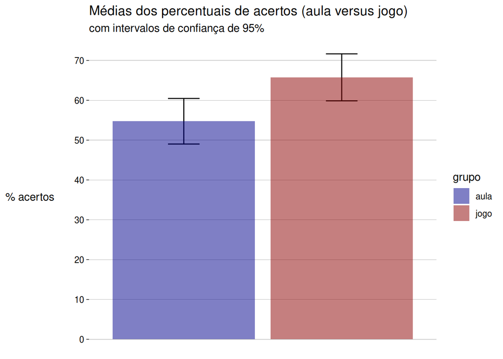

```r
intervalos %>% construir_plot_intervalos()
```

## Teste t

Para verificar se a diferença entre as médias dos percentuais de acertos é significativa, as seguintes hipóteses foram formuladas:

- A *hipótese de nulidade* $H_0$ diz que a média dos percentuais de acertos no grupo `jogo` ($\mu_\text{jogo}$) é *igual* à média dos percentuais de acertos no grupo `aula` ($\mu_\text{aula}$):

  $$H_0 : \mu_\text{jogo} = \mu_\text{aula}$$
- A *hipótese alternativa* $H_A$ diz que a média dos percentuais de acertos no grupo `jogo` ($\mu_\text{jogo}$) é *maior* do que a média dos percentuais de acertos no grupo `aula` ($\mu_\text{aula}$):

  $$H_A : \mu_\text{jogo} > \mu_\text{aula}$$

```r
t <- t.test(
  df %>% filter(grupo == 'jogo') %>% pull(pct),
  df %>% filter(grupo == 'aula') %>% pull(pct),
  alternative = 'greater',
  var.equal = TRUE
)

t
```

```
    Two Sample t-test

data:  df %>% filter(grupo == "jogo") %>% pull(pct) and df %>% filter(grupo == "aula") %>% pull(pct)
t = 2,7321, df = 64, p-value = 0,004062
alternative hypothesis: true difference in means is greater than 0
95 percent confidence interval:
 4,289076      Inf
sample estimates:
mean of x mean of y
 65,76370  54,74096
```

Um *teste t* com $\alpha = 0{,}01$ rejeita a hipótese de nulidade com um valor-$p$ igual a $0{,}00406$, mostrando que *a diferença é significativa*.

Em outras palavras: se o jogo não tivesse efeito sobre o desempenho dos participantes no questionário, então uma diferença como a observada no experimento (ou maior) teria uma probabilidade muito pequena (de cerca de $0{,}41$%) de ocorrer.